# Cours 1 : Les fonctions

Exercices

# Exemple d’utilisation

Ecrire une fonction qui, à partir d’une variable, effectue les étapes suivantes :

- Affiche le nombre de données manquante s’il y en a ;
- Impute les données manquantes par la moyenne ;
- Représente un histogramme des données après imputation ;
- Et retourne à l’utilisateur un `summary()` de la variable après imputation.

```
## Le nombre de données manquantes est 1
```

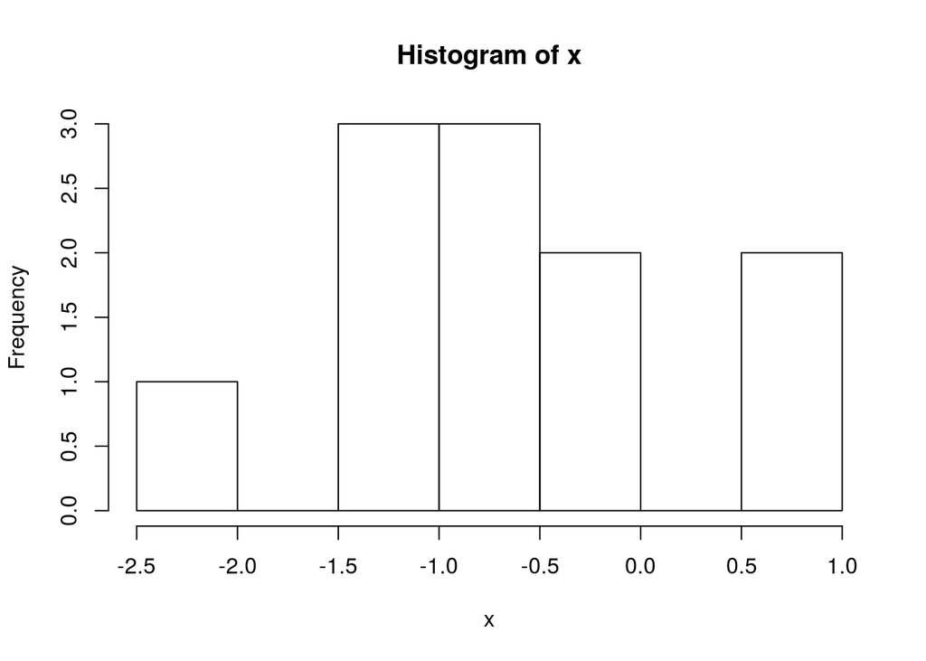

```
##    Min. 1st Qu.  Median    Mean 3rd Qu.    Max.
## -2.0120 -1.1700 -0.6264 -0.6264 -0.1833  0.7258
```

```r
impute_and_describe <- function(x) {
  if (any(is.na(x))) {
    message(paste(
      "Le nombre de données manquantes est",
      sum(is.na(x))
    ))
  }
  x[is.na(x)] <- mean(x, na.rm = TRUE)
  hist(x)
  summary(x)
}
impute_and_describe(c(rnorm(10), NA))
```

# Le lexical scoping

Ecrire une fonction spécifique à un jeu de données. Par exemple à partir du jeu de données `infert`, une fonction :

- Qui prend comme argument le nom d’une variable ;
- Et retourne la force d’association de cette variable avec la variable `case` (cas ou témoin) ;
- Sans prendre `infert` comme argument.

```r
assoc_case_infert <- function(x) {
  if (is.numeric(infert[, x])) {
    t.test(
      infert[infert$case == 0, x],
      infert[infert$case == 1, x]
    )
  } else {
    chisq.test(table(
      infert$case,
      infert[, x]
    ))
  }
}
assoc_case_infert("age")
```

```
##
##  Welch Two Sample t-test
##
## data:  infert[infert$case == 0, x] and infert[infert$case == 1, x]
## t = -0.055288, df = 163.77, p-value = 0.956
## alternative hypothesis: true difference in means is not equal to 0
## 95 percent confidence interval:
##  -1.439600  1.361177
## sample estimates:
## mean of x mean of y
##  31.49091  31.53012
```

```r
assoc_case_infert("education")
```

```
##
##  Pearson's Chi-squared test
##
## data:  table(infert$case, infert[, x])
## X-squared = 0.0022896, df = 2, p-value = 0.9989
```

`infert` est recherché dans l’environnement où `f()` est définie. Si on appelle `f()` depuis une fonction où on défini un autre jeu de données `infert` on risque d’avoir des surprises.

Exemple : faire une fonction qui rééchantillonne `infert`, le modifie, et appelle à nouveau `assoc_case_infert()`.

```r
resample_and_test <- function(x) {
  resamp <- sample(
    seq_len(nrow(infert)),
    size = nrow(infert),
    replace = TRUE
  )
  infert <- infert[resamp, ]
  assoc_case_infert(x)
}
resample_and_test("age")
```

```
##
##  Welch Two Sample t-test
##
## data:  infert[infert$case == 0, x] and infert[infert$case == 1, x]
## t = -0.055288, df = 163.77, p-value = 0.956
## alternative hypothesis: true difference in means is not equal to 0
## 95 percent confidence interval:
##  -1.439600  1.361177
## sample estimates:
## mean of x mean of y
##  31.49091  31.53012
```

Ca ne fonctionne pas car le `infert` utilisé par la fonction `assoc_case_infert()` est toujours celui de son *enclosing environment*, l’environnement global, et pas l’`infert` de son *calling environment*, l’*execution environment* de `resample_and_test()`.

# Manipulation des arguments

Ecrire une fonction qui a les proprités suivantes :

- Prend 2 arguments `x` et `y` ;
- Représente un nuage de points des arguments ;
- `x` a comme valeur par défault 10 valeurs aléatoires entre 0 et 1 ;
- Si `y` est manquant alors `x` est représenté en ordonnée, selon son index en abcisse.

```r
myplot1 <- function(x = runif(10), y) {
  if(missing(y)) {
    y <- x
    x <- seq_along(y)
  }
  plot(x, y)
}
```

Autre exercice : pareil, mais si `y` est manquant il prend les valeurs des index de `x`.

```r
myplot2 <- function(x = runif(10), y = seq_along(x)) {
  plot(x, y)
}
```

# Dot Dot Dot (`...`)

Faire un fonction qui prend comme argument un nombre de points et représente un nuage de points aléatoirement généré selon un distribution normale. Les paramètres de `plot()` doivent pouvoir être modifiés depuis la fonction.

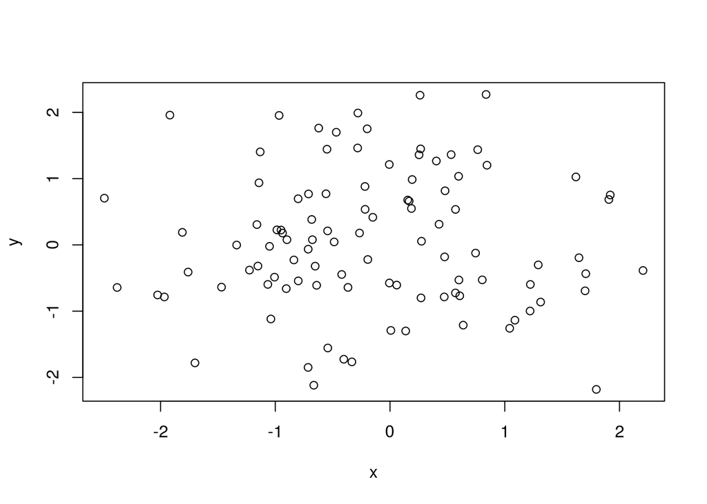

```r
random_scatter <- function(n, ...) {
  x <- rnorm(n)
  y <- rnorm(n)

  plot(x, y, ...)
}
random_scatter(100)
```

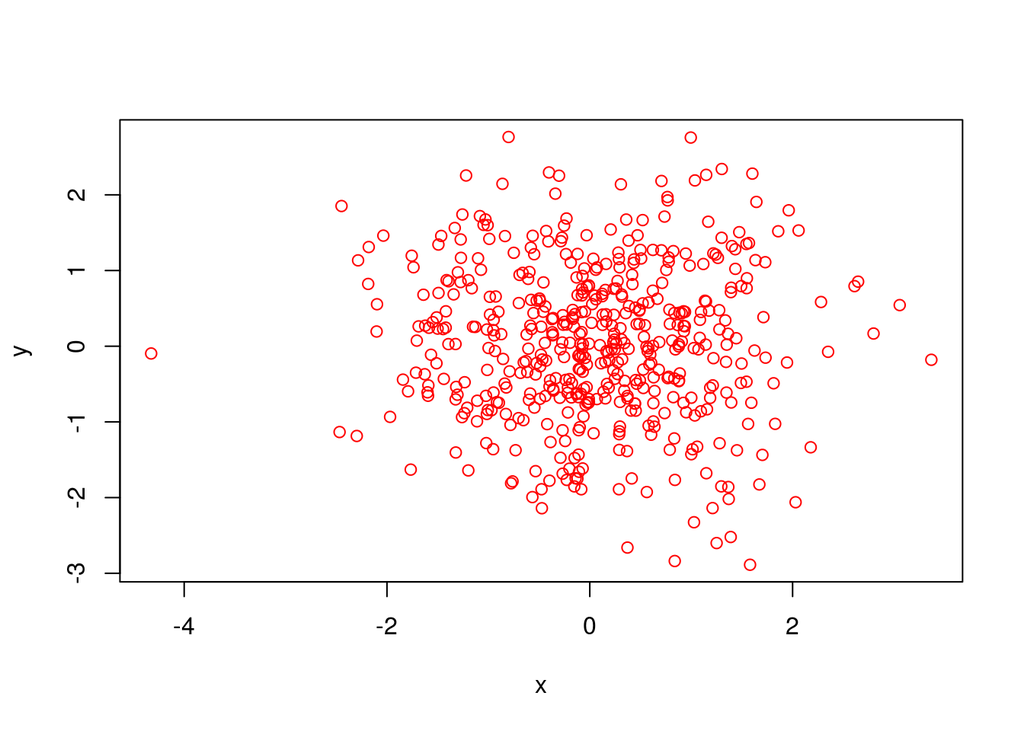

```r
random_scatter(500, col = "red")
```

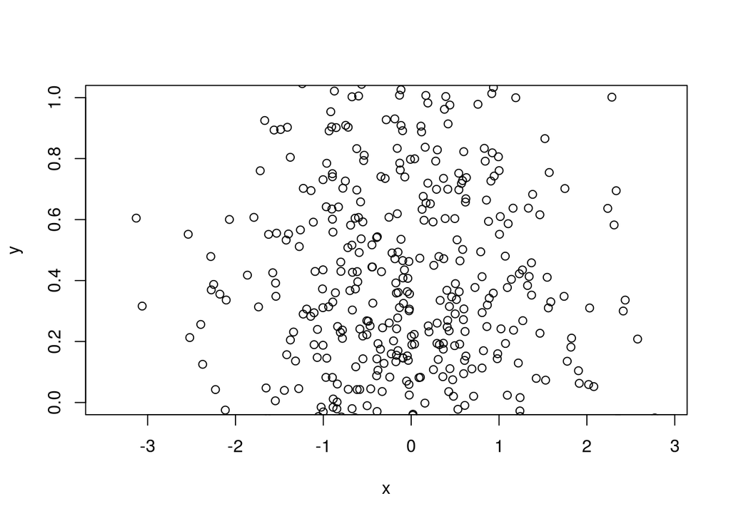

```r
random_scatter(1000, ylim = c(0, 1))
```

Faire une fonction qui à partir d’un nombre arbitraire de `t.test()` retourne le plus significatif.[^1]

```r
most_signif_ttest <- function(...) {
  list_ttest <- list(...)

  extract_p <- function(x)
    x$p.value

  pvals <- unlist(lapply(list_ttest, extract_p))

  list_ttest[[which(pvals == min(pvals))]]
}
most_signif_ttest(
  t.test(rnorm(10), rnorm(10)),
  t.test(rnorm(10), rnorm(10)),
  t.test(rnorm(10), rnorm(10)),
  t.test(rnorm(10), rnorm(10))
)
```

```
##
##  Welch Two Sample t-test
##
## data:  rnorm(10) and rnorm(10)
## t = 1.1629, df = 13.932, p-value = 0.2644
## alternative hypothesis: true difference in means is not equal to 0
## 95 percent confidence interval:
##  -0.4425432  1.4897989
## sample estimates:
##  mean of x  mean of y
##  0.1716437 -0.3519842
```

## Valeurs de retour complexes

Faire une fonction qui retourne pour une variable :

- Sa moyenne ;
- Son étendue ;
- La comparaison de sa moyenne à 0.

```r
some_stats <- function(x) {
  list(
    moyenne = mean(x),
    etendue = range(x),
    test0 = t.test(x)
  )
}
some_stats(rnorm(10))
```

```
## $moyenne
## [1] 0.3522191
##
## $etendue
## [1] -1.222609  2.460655
##
## $test0
##
##  One Sample t-test
##
## data:  x
## t = 0.99285, df = 9, p-value = 0.3467
## alternative hypothesis: true mean is not equal to 0
## 95 percent confidence interval:
##  -0.4502939  1.1547321
## sample estimates:
## mean of x
## 0.3522191
```

Faire une fonction qui impute les valeurs manquantes par la moyenne, retourne un vecteur, mais garde la trace de quelles valeurs sont imputées.

```r
impute_mean <- function(x) {
  res <- x
  res[is.na(x)] <- mean(x, na.rm = TRUE)

  attr(res, "imputed") <- is.na(x)
  res
}

(test <- impute_mean(c(1, 2, NA, 3)))
```

```
## [1] 1 2 2 3
## attr(,"imputed")
## [1] FALSE FALSE  TRUE FALSE
```

```r
attr(test, "imputed")
```

```
## [1] FALSE FALSE  TRUE FALSE
```

# Une fonction argument d’une fonction

Reprendre l’exemple précédent, mais utiliser une fonction arbitraire pour faire l’imputation. Du coup la fonction arbitraire prend peut-être d’autres arguments arbitraires ?

```r
impute_generalized <- function(x, f, ...) {
  res <- x
  res[is.na(x)] <- f(na.omit(x), ...)

  attr(res, "imputed") <- is.na(x)
  res
}
x <- c(1, 2, NA, 3)
impute_generalized(x, quantile, probs = .25)
```

```
## [1] 1.0 2.0 1.5 3.0
## attr(,"imputed")
## [1] FALSE FALSE  TRUE FALSE
```

[^1]: Plus avancé, utilise `lapply()` (prévu pour la leçon suivante).